# Machine learning and accelerometers

## Variable importance

Also, it is important to know which variable are the most important in the two models.

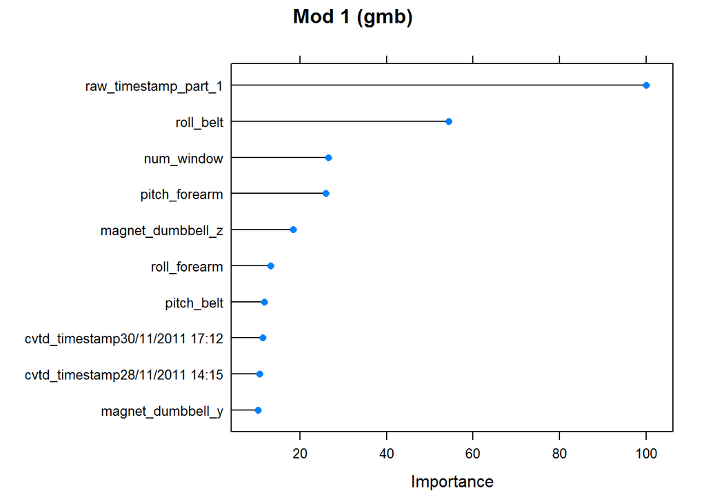

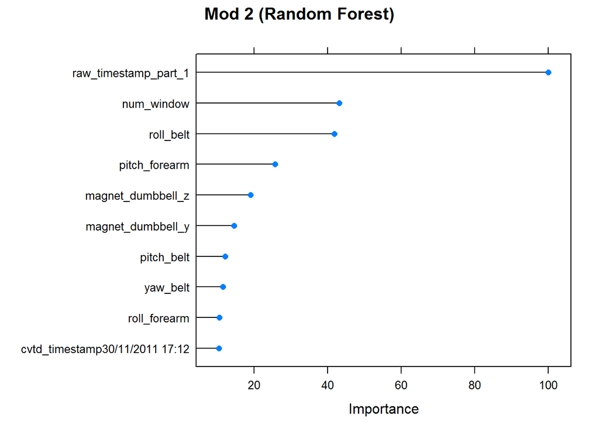

```r
plot(varImp(mod1),10, main = "Mod 1 (gmb)")
plot(varImp(mod2),10, main = "Mod 2 (Random Forest)")
```

## Prediction with the test dataset

Both model were used to predict the class variable in the test dataset. The results were the same:

```r
predict(mod1,test0)->p3
predict(mod2,test0)->p4
all(p3 == p4)
```

```
## [1] TRUE
```

## Conclussion

- The models have high accuracy and Kappa statistic evaluated using cross-validation, the out sample error is low
- The most important variable in the models are similar
- Both models predict the same class variable in the test dataset, hence both could be used.